# QOLIE-31/QOLIE-AD-48 Timeline, Scores, and Hypothesis Tests

Astrid

2022-09-16

# Source Data

BRIDGE follow-up QOLIE 31 & 48 dataset for all sites. Data in this version was pulled on 8/8/2022.

Info used later:  
- age(dob), - gender, - sites.

# QOLIE-31

Please refer to qolie31_survey.pdf and qolie31_scoring.pdf for original scale details.

## QOLIE-31 missing regions check

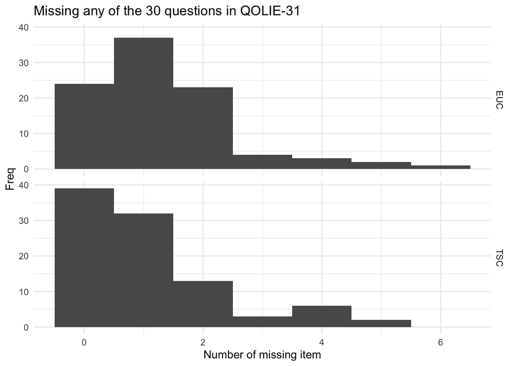

Missing any item or any domain (missing overall score?)

| study_arm | n | miss_any_item | miss_any_domain | miss_all |
| --- | --- | --- | --- | --- |
| EUC | 94 | 70 | 1 | 0 |
| TSC | 95 | 56 | 0 | 0 |

By visit

| study_arm | redcap_repeat_instance | n | miss_any_item | miss_any_domain | miss_all |
| --- | --- | --- | --- | --- | --- |
| EUC | 0 | 1 | 1 | 0 | 0 |
| EUC | 1 | 24 | 17 | 1 | 0 |
| EUC | 2 | 15 | 12 | 0 | 0 |
| EUC | 3 | 54 | 40 | 0 | 0 |
| TSC | 1 | 25 | 19 | 0 | 0 |
| TSC | 2 | 17 | 9 | 0 | 0 |
| TSC | 3 | 53 | 28 | 0 | 0 |

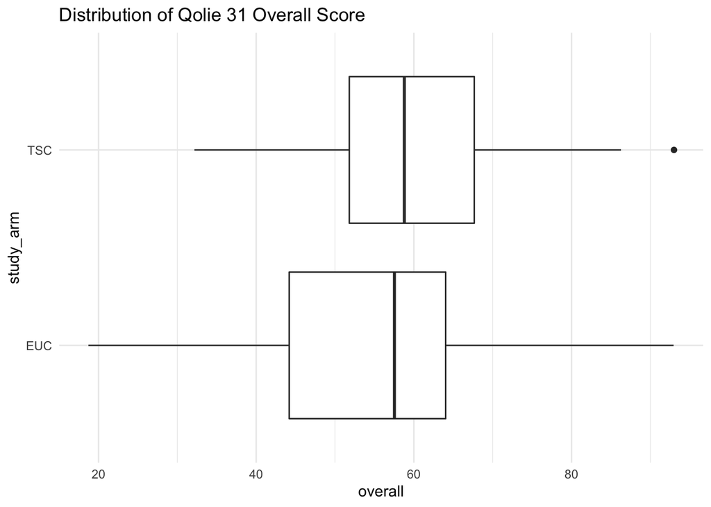

QOLIE-31

| item | TSC_total | TSC_N | TSC_per_patient | EUC_total | EUC_N | EUC_per_patient | diff |
| --- | --- | --- | --- | --- | --- | --- | --- |
| Average score per patient | 4741.247 | 80 | 59.26558 | 4070.534 | 72 | 56.53519 | 2.73039 |

QOLIE-31 Split up follow-up

| visit | TSC_total | TSC_N | TSC_per_patient | EUC_total | EUC_N | EUC_per_patient | diff |
| --- | --- | --- | --- | --- | --- | --- | --- |
| 1 | 1442.5955 | 25 | 57.70382 | 1214.4691 | 23 | 52.80300 | 4.9008157 |
| 2 | 910.5023 | 17 | 53.55896 | 799.1819 | 15 | 53.27879 | 0.2801655 |
| 3 | 3261.8038 | 53 | 61.54347 | 3110.6284 | 54 | 57.60423 | 3.9392383 |
| 0 | NA | NA | NA | 57.5357 | 1 | 57.53570 | NA |

| gender | visit | TSC_total | TSC_N | TSC_per_patient | EUC_total | EUC_N | EUC_per_patient | diff |
| --- | --- | --- | --- | --- | --- | --- | --- | --- |
| Male | 1 | 803.7675 | 14 | 57.41196 | 975.2363 | 18 | 54.17979 | 3.2321698 |
| Male | 2 | 467.5209 | 9 | 51.94677 | 375.4604 | 8 | 46.93255 | 5.0142167 |
| Male | 3 | 2504.5720 | 40 | 62.61430 | 1892.3455 | 33 | 57.34380 | 5.2704970 |
| Female | 0 | NA | NA | NA | 57.5357 | 1 | 57.53570 | NA |
| Female | 1 | 638.8280 | 11 | 58.07527 | 239.2328 | 5 | 47.84656 | 10.2287127 |
| Female | 2 | 442.9814 | 8 | 55.37268 | 423.7215 | 7 | 60.53164 | -5.1589679 |
| Female | 3 | 757.2318 | 13 | 58.24860 | 1218.2829 | 21 | 58.01347 | 0.2351286 |

## QOLIE 31 Hypothesis Testing

The records separately for every id are not enough.

```
##
## Call:
## lm(formula = overall ~ factor(study_arm) + factor(redcap_repeat_instance) +
##     factor(study_arm):factor(redcap_repeat_instance), data = q31info)
##
## Residuals:
##     Min      1Q  Median      3Q     Max
## -38.887  -8.883   0.119   8.536  39.441
##
## Coefficients: (1 not defined because of singularities)
##                                                      Estimate Std. Error
## (Intercept)                                          57.53570   13.75589
## factor(study_arm)TSC                                  3.93924    2.65978
## factor(redcap_repeat_instance)1                      -4.73270   14.05175
## factor(redcap_repeat_instance)2                      -4.25691   14.20702
## factor(redcap_repeat_instance)3                       0.06853   13.88267
## factor(study_arm)TSC:factor(redcap_repeat_instance)1  0.96158    4.78232
## factor(study_arm)TSC:factor(redcap_repeat_instance)2 -3.65907    5.55160
## factor(study_arm)TSC:factor(redcap_repeat_instance)3       NA         NA
##                                                      t value Pr(>|t|)
## (Intercept)                                            4.183 4.49e-05 ***
## factor(study_arm)TSC                                   1.481    0.140
## factor(redcap_repeat_instance)1                       -0.337    0.737
## factor(redcap_repeat_instance)2                       -0.300    0.765
## factor(redcap_repeat_instance)3                        0.005    0.996
## factor(study_arm)TSC:factor(redcap_repeat_instance)1   0.201    0.841
## factor(study_arm)TSC:factor(redcap_repeat_instance)2  -0.659    0.511
## factor(study_arm)TSC:factor(redcap_repeat_instance)3      NA       NA
## ---
## Signif. codes:  0 '***' 0.001 '**' 0.01 '*' 0.05 '.' 0.1 ' ' 1
##
## Residual standard error: 13.76 on 181 degrees of freedom
##   (1 observation deleted due to missingness)
## Multiple R-squared:  0.05272,    Adjusted R-squared:  0.02131
## F-statistic: 1.679 on 6 and 181 DF,  p-value: 0.1285
```

```
##
## Call:
## lm(formula = overall ~ factor(study_arm) + factor(redcap_repeat_instance) +
##     factor(gender), data = q31info)
##
## Residuals:
##     Min      1Q  Median      3Q     Max
## -38.977  -8.650   0.337   8.716  37.742
##
## Coefficients:
##                                 Estimate Std. Error t value Pr(>|t|)
## (Intercept)                      57.5357    13.7395   4.188 4.39e-05 ***
## factor(study_arm)TSC              3.5687     2.0113   1.774   0.0777 .
## factor(redcap_repeat_instance)1  -3.8418    13.9906  -0.275   0.7839
## factor(redcap_repeat_instance)2  -5.8469    14.0367  -0.417   0.6775
## factor(redcap_repeat_instance)3   0.4538    13.9126   0.033   0.9740
## factor(gender)2                  -0.2957     2.1250  -0.139   0.8895
## ---
## Signif. codes:  0 '***' 0.001 '**' 0.01 '*' 0.05 '.' 0.1 ' ' 1
##
## Residual standard error: 13.74 on 182 degrees of freedom
##   (1 observation deleted due to missingness)
## Multiple R-squared:  0.04974,    Adjusted R-squared:  0.02364
## F-statistic: 1.905 on 5 and 182 DF,  p-value: 0.09546
```

```
##
## Call:
## lm(formula = overall ~ factor(study_arm) + factor(redcap_repeat_instance) +
##     factor(city), data = q31info)
##
## Residuals:
##     Min      1Q  Median      3Q     Max
## -35.946  -7.800  -0.210   9.306  41.882
##
## Coefficients:
##                                 Estimate Std. Error t value Pr(>|t|)
## (Intercept)                       64.403     13.802   4.666 5.95e-06 ***
## factor(study_arm)TSC               3.316      1.992   1.665   0.0977 .
## factor(redcap_repeat_instance)1   -6.948     13.745  -0.505   0.6138
## factor(redcap_repeat_instance)2   -9.733     13.852  -0.703   0.4832
## factor(redcap_repeat_instance)3   -2.873     13.687  -0.210   0.8340
## factor(city)Kano                  -2.572      2.745  -0.937   0.3499
## factor(city)Zaria                 -6.867      2.769  -2.480   0.0141 *
## ---
## Signif. codes:  0 '***' 0.001 '**' 0.01 '*' 0.05 '.' 0.1 ' ' 1
##
## Residual standard error: 13.52 on 181 degrees of freedom
##   (1 observation deleted due to missingness)
## Multiple R-squared:  0.08471,    Adjusted R-squared:  0.05437
## F-statistic: 2.792 on 6 and 181 DF,  p-value: 0.01274
```

# QOLIE-AD-48

Please refer to Cramer 1999 QOLIE-AD-48.pdf for original scale details.

Question 16 and 18 are missing from the survey.

- 16. Had a problem with complicated projects that require organization or planning like computer games or difficult homework)?
- 18. Had trouble finding the correct word?

Question 47 looks slightly different in order and preset (currently included in results):

- Original instrumentL 47. Feel that your epilepsy kept you from doing things you like to do?  
  The following questions ask about your attitudes toward epilepsy. Circle one number for how often in the past 4 weeks you have had these attitudes. [Very (negative) = 1, A little (negative) = 2, Not sure = 3, A little (positive) = 4, Very (positive) = 51.
- In our survey: The following questions are about your regular daily activities, such as chores at home, baby -sitting, going to school, gathering with friends and family, dong homework, or an extra activity after school. We want to know if you had an of the following difficulties with your regular activities as a result of any physical problems such as an illness or emotional problems, such as feeling sad or nervous.  
  In the past four weeks, how often have physical or emotional problems caused you to: Do fewer things than you would have liked to do? 1 Very often  
  2 Often  
  3 Sometimes  
  4 Not often  
  5 Never

**as ZZ, We decided to ignore the two missing questions and treat the slightly different question 47 same as the original one in scoring.**

One more question: there’s two 27 in Cramer(1999), based on the context, which should be a typo.

## QOLIE-48 missing regions check

Missing any item or any domain (missing overall score?)

| study_arm | n | miss_any_item | miss_any_domain | miss_all |
| --- | --- | --- | --- | --- |
| EUC | 885 | 242 | 11 | 0 |
| TSC | 933 | 229 | 8 | 0 |

By visit

| study_arm | redcap_repeat_instance | n | miss_any_item | miss_any_domain | miss_all |
| --- | --- | --- | --- | --- | --- |
| EUC | 0 | 182 | 57 | 2 | 0 |
| EUC | 1 | 234 | 76 | 1 | 0 |
| EUC | 2 | 321 | 78 | 6 | 0 |
| EUC | 3 | 148 | 31 | 2 | 0 |
| TSC | 0 | 215 | 54 | 3 | 0 |
| TSC | 1 | 237 | 64 | 1 | 0 |
| TSC | 2 | 339 | 81 | 4 | 0 |
| TSC | 3 | 142 | 30 | 0 | 0 |

Missing any item

| study_arm | miss_any | n |
| --- | --- | --- |
| EUC | 0 | 643 |
| EUC | 1 | 242 |
| TSC | 0 | 704 |
| TSC | 1 | 229 |

Missing any domain (missing overall score?)

| study_arm | n | miss_any_domain | miss_all |
| --- | --- | --- | --- |
| EUC | 885 | 11 | 0 |
| TSC | 933 | 8 | 0 |

Missing any domain (missing overall score?)

| study_arm | redcap_repeat_instance | n | miss_any_domain | miss_all |
| --- | --- | --- | --- | --- |
| EUC | 0 | 182 | 2 | 0 |
| EUC | 1 | 234 | 1 | 0 |
| EUC | 2 | 321 | 6 | 0 |
| EUC | 3 | 148 | 2 | 0 |
| TSC | 0 | 215 | 3 | 0 |
| TSC | 1 | 237 | 1 | 0 |
| TSC | 2 | 339 | 4 | 0 |
| TSC | 3 | 142 | 0 | 0 |

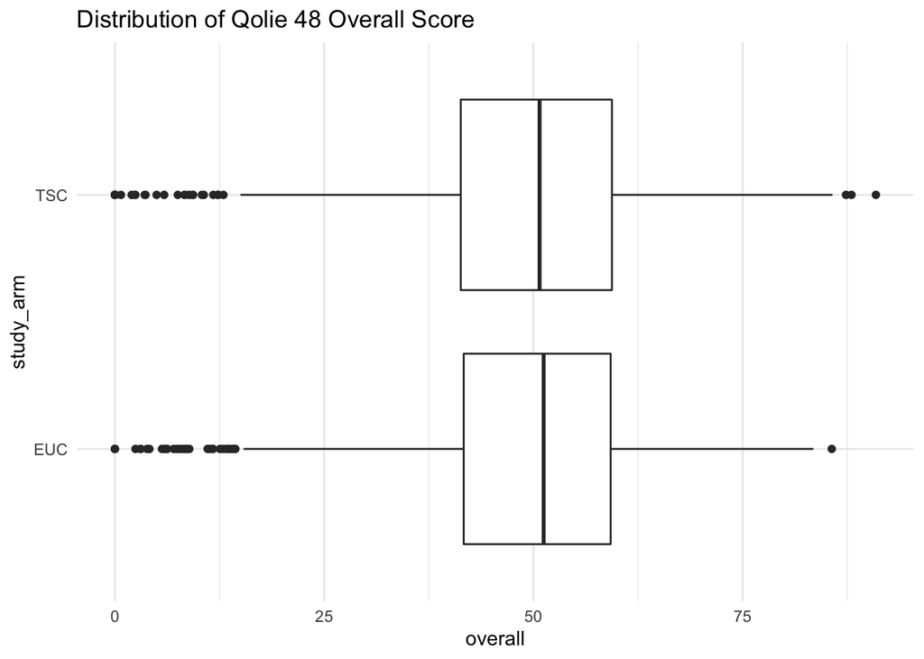

QOLIE-48

| item | TSC_total | TSC_N | TSC_per_patient | EUC_total | EUC_N | EUC_per_patient | diff |
| --- | --- | --- | --- | --- | --- | --- | --- |
| Average score per patient | 21287.71 | 427 | 49.85412 | 20681.16 | 414 | 49.95448 | -0.1003664 |

QOLIE-48 Split up follow-up

| visit | TSC_total | TSC_N | TSC_per_patient | EUC_total | EUC_N | EUC_per_patient | diff |
| --- | --- | --- | --- | --- | --- | --- | --- |
| 0 | 10408.808 | 212 | 49.09815 | 8257.076 | 180 | 45.87264 | 3.225505 |
| 1 | 11293.314 | 236 | 47.85302 | 11387.475 | 233 | 48.87328 | -1.020258 |
| 2 | 16546.786 | 335 | 49.39339 | 15909.220 | 315 | 50.50546 | -1.112070 |
| 3 | 7544.645 | 142 | 53.13130 | 7399.981 | 146 | 50.68480 | 2.446500 |

QOLIE-48 Split up follow-up and gender

| gender | visit | TSC_total | TSC_N | TSC_per_patient | EUC_total | EUC_N | EUC_per_patient | diff |
| --- | --- | --- | --- | --- | --- | --- | --- | --- |
| Male | 0 | 7145.024 | 144 | 49.61822 | 5366.158 | 120 | 44.71799 | 4.9002378 |
| Male | 1 | 7189.495 | 148 | 48.57767 | 7263.302 | 148 | 49.07636 | -0.4986982 |
| Male | 2 | 10626.788 | 215 | 49.42692 | 10158.679 | 198 | 51.30646 | -1.8795392 |
| Male | 3 | 4528.723 | 86 | 52.65957 | 4372.418 | 88 | 49.68656 | 2.9730008 |
| Female | 0 | 3263.783 | 68 | 47.99681 | 2890.917 | 60 | 48.18196 | -0.1851454 |
| Female | 1 | 4103.819 | 88 | 46.63431 | 4124.173 | 85 | 48.51968 | -1.8853727 |
| Female | 2 | 5919.998 | 120 | 49.33331 | 5750.541 | 117 | 49.14992 | 0.1833936 |
| Female | 3 | 3015.922 | 56 | 53.85575 | 3027.563 | 58 | 52.19937 | 1.6563869 |

## QOLIE-AD-48 Hypothesis Testing

Focus on the interaction of study arm and instances.

```
##
## Call:
## lm(formula = overall ~ factor(study_arm) + factor(redcap_repeat_instance) +
##     factor(study_arm):factor(redcap_repeat_instance), data = q48info)
##
## Residuals:
##     Min      1Q  Median      3Q     Max
## -53.131  -8.153   1.493   9.994  41.819
##
## Coefficients:
##                                                      Estimate Std. Error
## (Intercept)                                            45.873      1.167
## factor(study_arm)TSC                                    3.225      1.587
## factor(redcap_repeat_instance)1                         3.001      1.554
## factor(redcap_repeat_instance)2                         4.633      1.463
## factor(redcap_repeat_instance)3                         4.812      1.744
## factor(study_arm)TSC:factor(redcap_repeat_instance)1   -4.246      2.147
## factor(study_arm)TSC:factor(redcap_repeat_instance)2   -4.338      2.007
## factor(study_arm)TSC:factor(redcap_repeat_instance)3   -0.779      2.434
##                                                      t value Pr(>|t|)
## (Intercept)                                           39.312  < 2e-16 ***
## factor(study_arm)TSC                                   2.033  0.04222 *
## factor(redcap_repeat_instance)1                        1.931  0.05359 .
## factor(redcap_repeat_instance)2                        3.167  0.00157 **
## factor(redcap_repeat_instance)3                        2.760  0.00584 **
## factor(study_arm)TSC:factor(redcap_repeat_instance)1  -1.978  0.04810 *
## factor(study_arm)TSC:factor(redcap_repeat_instance)2  -2.161  0.03080 *
## factor(study_arm)TSC:factor(redcap_repeat_instance)3  -0.320  0.74893
## ---
## Signif. codes:  0 '***' 0.001 '**' 0.01 '*' 0.05 '.' 0.1 ' ' 1
##
## Residual standard error: 15.66 on 1791 degrees of freedom
##   (19 observations deleted due to missingness)
## Multiple R-squared:  0.01234,    Adjusted R-squared:  0.008476
## F-statistic: 3.196 on 7 and 1791 DF,  p-value: 0.002289
```

```
##
## Call:
## lm(formula = overall ~ factor(study_arm) + factor(redcap_repeat_instance) +
##     factor(gender), data = q48info)
##
## Residuals:
##     Min      1Q  Median      3Q     Max
## -52.213  -8.270   1.640   9.901  43.289
##
## Coefficients:
##                                 Estimate Std. Error t value Pr(>|t|)
## (Intercept)                      47.2057     1.0262  45.998  < 2e-16 ***
## factor(study_arm)TSC              0.4215     0.7399   0.570  0.56895
## factor(redcap_repeat_instance)1   0.7702     1.0736   0.717  0.47322
## factor(redcap_repeat_instance)2   2.3364     1.0031   2.329  0.01996 *
## factor(redcap_repeat_instance)3   4.3130     1.2183   3.540  0.00041 ***
## factor(gender)2                   0.2723     0.7697   0.354  0.72356
## ---
## Signif. codes:  0 '***' 0.001 '**' 0.01 '*' 0.05 '.' 0.1 ' ' 1
##
## Residual standard error: 15.68 on 1793 degrees of freedom
##   (19 observations deleted due to missingness)
## Multiple R-squared:  0.008612,   Adjusted R-squared:  0.005847
## F-statistic: 3.115 on 5 and 1793 DF,  p-value: 0.008354
```

```
##
## Call:
## lm(formula = overall ~ factor(study_arm) + factor(redcap_repeat_instance) +
##     factor(city), data = q48info)
##
## Residuals:
##     Min      1Q  Median      3Q     Max
## -50.440  -8.393   1.294  10.158  47.407
##
## Coefficients:
##                                 Estimate Std. Error t value Pr(>|t|)
## (Intercept)                      46.3748     1.0727  43.230  < 2e-16 ***
## factor(study_arm)TSC              0.2207     0.7262   0.304  0.76123
## factor(redcap_repeat_instance)1   1.3876     1.0543   1.316  0.18828
## factor(redcap_repeat_instance)2   2.0327     0.9831   2.068  0.03881 *
## factor(redcap_repeat_instance)3   4.4422     1.1996   3.703  0.00022 ***
## factor(city)Kano                  4.1868     0.9367   4.470 8.32e-06 ***
## factor(city)Zaria                -3.0859     1.0171  -3.034  0.00245 **
## ---
## Signif. codes:  0 '***' 0.001 '**' 0.01 '*' 0.05 '.' 0.1 ' ' 1
##
## Residual standard error: 15.36 on 1792 degrees of freedom
##   (19 observations deleted due to missingness)
## Multiple R-squared:  0.04885,    Adjusted R-squared:  0.04566
## F-statistic: 15.34 on 6 and 1792 DF,  p-value: < 2.2e-16
```

# Whole Timeline

for every record id, put all the records together

## Baseline date

Zilu learnt from Lizet that participants could “enroll” through either the screening or the follow up project. If ev0=1 (screening) then use date_consent_screen, if ev0=0 (follow-up) then dataconsentenroll.

Zilu confirmed in data that only participants who enrolled via follow-up have a dateconsentenroll value (a handful of missing date). In most cases, the consent enroll date is about a week after consent screening date.

A question need to solve later for time series analysis.

```
##    de_screen              de_fu            date_baseline
##  Min.   :2020-06-15   Min.   :2020-06-17   Min.   :2020-06-16
##  1st Qu.:2020-08-07   1st Qu.:2020-07-20   1st Qu.:2020-08-13
##  Median :2020-09-23   Median :2020-09-02   Median :2020-09-28
##  Mean   :2020-10-13   Mean   :2020-09-11   Mean   :2020-10-17
##  3rd Qu.:2020-11-25   3rd Qu.:2020-10-07   3rd Qu.:2020-11-27
##  Max.   :2021-08-21   Max.   :2021-08-20   Max.   :2021-08-21
##  NA's   :1            NA's   :1183         NA's   :21
```

```
##    Min. 1st Qu.  Median    Mean 3rd Qu.    Max.    NA's
##  -5.000   5.000   7.000   9.898  11.000  88.000    1183
```

[output not shown]

```
## Not sure which date to use as baseline, missingness could be an issue
```

## Try to look into all the qolie times for every participant

difference between baseline date and Screening QOLIE-48 Date

| ev0 | datediff | n |
| --- | --- | --- |
| 0 | 0 days | 8 |
| 1 | -314 days | 1 |
| 1 | -2 days | 1 |
| 1 | -1 days | 1 |
| 1 | 0 days | 311 |
| 1 | 1 days | 32 |
| 1 | 2 days | 14 |
| 1 | 3 days | 4 |
| 1 | 4 days | 10 |
| 1 | 5 days | 5 |
| 1 | 6 days | 5 |
| 1 | 7 days | 2 |
| 1 | 8 days | 1 |
| 1 | 9 days | 2 |
| 1 | 11 days | 3 |
| 1 | 14 days | 1 |
| 1 | 21 days | 1 |
| 1 | 50 days | 1 |

difference between baseline date and Instance 1 QOLIE-48 Date

| ev0 | datediff | n | n_sum |
| --- | --- | --- | --- |
| 0 | 0 days | 210 | 271 |
| 0 | 1 days | 2 | 271 |
| 0 | 2 days | 2 | 271 |
| 0 | 3 days | 2 | 271 |
| 0 | 4 days | 1 | 271 |
| 0 | 5 days | 2 | 271 |
| 0 | 6 days | 5 | 271 |
| 0 | 7 days | 13 | 271 |
| 0 | 9 days | 3 | 271 |
| 0 | 10 days | 1 | 271 |
| 0 | 13 days | 1 | 271 |
| 0 | 19 days | 1 | 271 |
| 0 | 20 days | 1 | 271 |
| 0 | 21 days | 1 | 271 |
| 0 | 28 days | 1 | 271 |
| 0 | 33 days | 2 | 271 |
| 0 | 35 days | 1 | 271 |
| 0 | 39 days | 1 | 271 |
| 0 | 44 days | 2 | 271 |
| 0 | 46 days | 1 | 271 |
| 0 | 56 days | 2 | 271 |
| 0 | 60 days | 1 | 271 |
| 0 | 63 days | 2 | 271 |
| 0 | 88 days | 1 | 271 |
| 0 | 665 days | 1 | 271 |
| 0 | 671 days | 1 | 271 |
| 0 | 672 days | 2 | 271 |
| 0 | 680 days | 1 | 271 |
| 0 | NA days | 7 | 271 |
| 1 | -174 days | 1 | 318 |

[output cut: 58 more lines]

All qolie records with dates and scores

| record_id | study_arm | qolietimes | ev0 | datebaseline | dateqolie | instance | type | score | miss_item | miss_domain |
| --- | --- | --- | --- | --- | --- | --- | --- | --- | --- | --- |
| PHC—154-85-2020-08-20 11:05 | EUC | 5 | 0 | 2020-08-24 | 2020-09-06 | 1 | QOLIE-AD-48 | 16.083333 | 0 | 0 |
| PHC-73—80-2020-09-09 09:30 | TSC | 5 | 1 | 2020-09-09 | 2020-09-09 | 0 | QOLIE-AD-48 | 63.282667 | 0 | 0 |
| PHC—141-119-2020-09-30 16:13 | TSC | 5 | 1 | 2020-09-30 | 2020-09-30 | 0 | QOLIE-AD-48 | 66.201333 | 0 | 0 |
| PHC—154-85-2020-08-20 11:05 | EUC | 5 | 0 | 2020-08-24 | 2020-10-19 | 2 | QOLIE-AD-48 | 16.083333 | 0 | 0 |
| PHC-73—80-2020-09-09 09:30 | TSC | 5 | 1 | 2020-09-09 | 2020-11-04 | 2 | QOLIE-AD-48 | 65.139583 | 0 | 0 |
| PHC—141-119-2020-09-30 16:13 | TSC | 5 | 1 | 2020-09-30 | 2020-11-25 | 1 | QOLIE-AD-48 | 53.695833 | 0 | 0 |
| PHC—141-119-2020-09-30 16:13 | TSC | 5 | 1 | 2020-09-30 | 2020-11-25 | 2 | QOLIE-AD-48 | 60.645667 | 0 | 0 |
| PHC—154-85-2020-08-20 11:05 | EUC | 5 | 0 | 2020-08-24 | 2022-06-27 | 3 | QOLIE-31 | 18.717000 | 1 | 0 |
| PHC-73—80-2020-09-09 09:30 | TSC | 5 | 1 | 2020-09-09 | 2022-07-04 | 1 | QOLIE-31 | 66.200600 | 1 | 0 |
| PHC-73—80-2020-09-09 09:30 | TSC | 5 | 1 | 2020-09-09 | 2022-07-04 | 3 | QOLIE-31 | 75.338100 | 1 | 0 |
| PHC-73—80-2020-09-09 09:30 | TSC | 5 | 1 | 2020-09-09 | 2022-07-05 | 3 | QOLIE-AD-48 | 73.008333 | 0 | 0 |
| PHC—141-119-2020-09-30 16:13 | TSC | 5 | 1 | 2020-09-30 | 2022-08-03 | 3 | QOLIE-AD-48 | 75.050000 | 0 | 0 |
| PHC—141-119-2020-09-30 16:13 | TSC | 5 | 1 | 2020-09-30 | 2022-08-03 | 3 | QOLIE-31 | 79.048500 | 0 | 0 |
| PHC—154-85-2020-08-20 11:05 | EUC | 5 | 0 | 2020-08-24 | NA | 2 | QOLIE-31 | 40.557500 | 2 | 0 |
| PHC—154-85-2020-08-20 11:05 | EUC | 5 | 0 | 2020-08-24 | NA | 1 | QOLIE-31 | 43.882500 | 1 | 0 |
| PHC–92–60-2020-06-28 07:29 | EUC | 4 | 1 | 2020-06-28 | 2020-06-28 | 1 | QOLIE-AD-48 | 51.263083 | 0 | 0 |
| PHC—131-39-2020-06-27 10:52 | TSC | 4 | 1 | 2020-06-27 | 2020-06-29 | 1 | QOLIE-31 | 32.160000 | 2 | 0 |
| PHC—131-39-2020-06-27 10:52 | TSC | 4 | 1 | 2020-06-27 | 2020-06-29 | 1 | QOLIE-AD-48 | 23.255705 | 1 | 0 |
| PHC—141-119-2020-07-01 11:26 | TSC | 4 | 1 | 2020-07-01 | 2020-07-01 | 1 | QOLIE-31 | 39.617000 | 2 | 0 |
| PHC—141-101-2020-06-30 11:40 | TSC | 4 | 0 | 2020-06-30 | 2020-07-01 | 1 | QOLIE-AD-48 | 37.731310 | 1 | 0 |
| PHC-61—54-2020-07-06 17:47 | EUC | 4 | 1 | 2020-07-06 | 2020-07-06 | 1 | QOLIE-AD-48 | 49.451333 | 0 | 0 |
| PHC-61—54-2020-07-06 17:47 | EUC | 4 | 1 | 2020-07-06 | 2020-07-07 | 1 | QOLIE-31 | 43.033300 | 0 | 0 |
| PHC—153-71-2020-07-08 10:39 | TSC | 4 | 1 | 2020-07-08 | 2020-07-08 | 1 | QOLIE-AD-48 | 40.036833 | 10 | 0 |
| PHC—141-101-2020-06-30 11:40 | TSC | 4 | 0 | 2020-06-30 | 2020-07-08 | 1 | QOLIE-31 | 48.420700 | 1 | 0 |
| PHC—131-72-2020-06-29 11:01 | TSC | 4 | 0 | 2020-07-08 | 2020-07-10 | 1 | QOLIE-AD-48 | 53.877167 | 0 | 0 |
| PHC—152-115-2020-07-13 11:58 | EUC | 4 | 1 | 2020-07-13 | 2020-07-13 | 0 | QOLIE-AD-48 | 4.125000 | 10 | 0 |
| PHC—152-115-2020-08-06 07:29 | EUC | 4 | 1 | 2020-07-22 | 2020-07-22 | 0 | QOLIE-AD-48 | 18.766143 | 8 | 0 |
| PHC—154-63-2020-07-15 17:04 | EUC | 4 | 1 | 2020-07-15 | 2020-07-23 | 1 | QOLIE-AD-48 | 59.533333 | 0 | 0 |
| PHC-12—23-2020-07-21 13:16 | EUC | 4 | 0 | 2020-08-05 | 2020-08-05 | 1 | QOLIE-AD-48 | 64.419643 | 5 | 0 |
| PHC—153-71-2020-08-04 10:43 | TSC | 4 | 1 | 2020-08-04 | 2020-08-05 | 0 | QOLIE-AD-48 | 28.159000 | 0 | 0 |

[output cut: 1977 more lines]

Next Step:

1. for those with 2 times of QOLIE on the same date:

   if one is QOLIE-AD-48, the other is QOLIE-31, choose the one consistent with the age;

   if both are the same instruments, use the more completed one / the later one.
2. for every record id, sort all the scores by time.
3. Check the time interval between 2 times of QOLIE.